# Final project — Internet usage around the world

STA 130 TUT110

## Introduction

- For this final project in STA 130, we were tasked with analyzing data from the World Factbook, published by the US Central Intelligence Agency (CIA)
- We wanted to look specifically at the internet usage, and how other factors relate to internet usage in different countries
- We used information on internet users, health expenditure, education expenditure, democracy index, GDP and population
- For this analysis we needed to answer three questions

## Objectives

- How did we define internet use?
- What can we conclude on internet use for different regions of the world
- What do we define as democracy, education, economy, and health and how is internet use affected by these factors?

## Definitions

- Internet use: The number of people who have use internet in any form at least a few times in a year
- Democracy: A mean score of different aspects of governments by The Economist Intelligence Unit
- Economy: A countries total GDP found using its population and GDP per capita
- Education: The total amount of the GDP spent on education
- Health: The total amount of the GDP spent on healthcare

## Data Summary Part 1

- We needed to clean the data that we were provided. So what did we do?
- Look for and change any name discrepancies between the data sets
- Change data that is a number counted as a string/character back into a numeric value
- Remove any regions or countries from the data sets that we are missing information for. Example below

```
## # A tibble: 1 x 3
##   Country         Region  `Global South`
##   <chr>           <chr>   <chr>
## 1 Anonymous Proxy Unknown Unknown
```

## Data Summary Part 2

- Remove any unnecessary rows & columns and add any that we needed. Example below

```
## # A tibble: 4 x 9
##   Rank  Country Score `Electoral proc… `Functioning of… Politicalpartic…
##   <chr> <chr>   <chr> <chr>            <chr>            <chr>
## 1 Rank  Country Score Electoral proce… Functioning ofg… Politicalpartic…
## 2 Rank  Country Score Electoral proce… Functioning ofg… Politicalpartic…
## 3 Rank  Country Score Electoral proce… Functioning ofg… Politicalpartic…
## 4 Rank  Country Score Electoral proce… Functioning ofg… Politicalpartic…
## # … with 3 more variables: Politicalculture <chr>, Civilliberties <chr>,
## #   Category <chr>
```

- We also created variables for the Total GDP, and the Total amounts spent on health and education. This is because GDP per capita is heavily affected by population and percentage of GDP by the total GDP

## Statistical Methods

Internet users and world regions with and without outlier

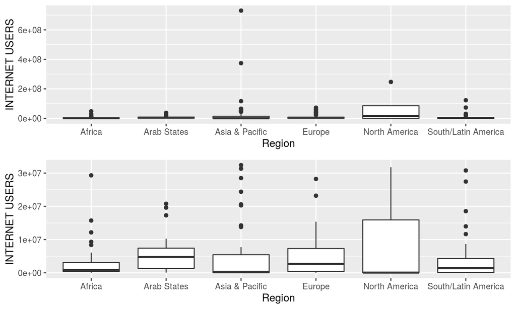

## Internet users and world region

```
##
## Call:
## lm(formula = `INTERNET USERS` ~ Region, data = iu_region)
##
## Residuals:
##       Min        1Q    Median        3Q       Max
## -69658720 -10302833  -6055889  -1749741 701089743
##
## Coefficients:
##                           Estimate Std. Error t value Pr(>|t|)
## (Intercept)                4202341    9359830   0.449   0.6539
## RegionArab States          3357727   16346241   0.205   0.8375
## RegionAsia & Pacific      25431876   12272798   2.072   0.0395 *
## RegionEurope               6152011   12571202   0.489   0.6251
## RegionNorth America       65460880   31393825   2.085   0.0383 *
## RegionSouth/Latin America  5070826   13495523   0.376   0.7075
## ---
## Signif. codes:  0 '***' 0.001 '**' 0.01 '*' 0.05 '.' 0.1 ' ' 1
##
## Residual standard error: 59930000 on 205 degrees of freedom
## Multiple R-squared:  0.04214,    Adjusted R-squared:  0.01878
## F-statistic: 1.804 on 5 and 205 DF,  p-value: 0.1135
```

## Internet users and population with and without outlier

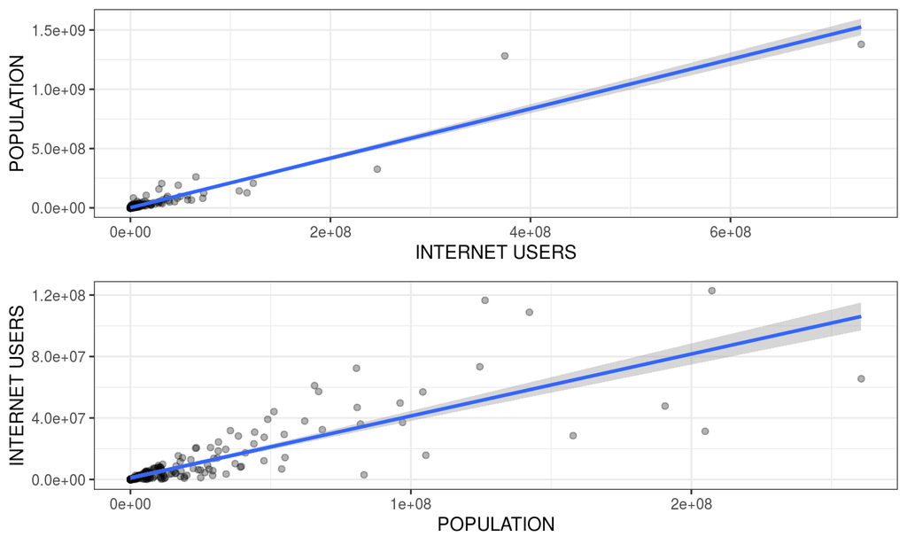

## Internet users and population

```
##
## Call:
## lm(formula = `INTERNET USERS` ~ POPULATION, data = iu_pop)
##
## Residuals:
##        Min         1Q     Median         3Q        Max
## -172976411   -1611667    -895957     836276  141919386
##
## Coefficients:
##              Estimate Std. Error t value Pr(>|t|)
## (Intercept) 9.139e+05  1.355e+06   0.674    0.501
## POPULATION  4.262e-01  1.009e-02  42.241   <2e-16 ***
## ---
## Signif. codes:  0 '***' 0.001 '**' 0.01 '*' 0.05 '.' 0.1 ' ' 1
##
## Residual standard error: 19710000 on 223 degrees of freedom
## Multiple R-squared:  0.8889, Adjusted R-squared:  0.8884
## F-statistic:  1784 on 1 and 223 DF,  p-value: < 2.2e-16
```

## Internet users and democracy with and without outlier

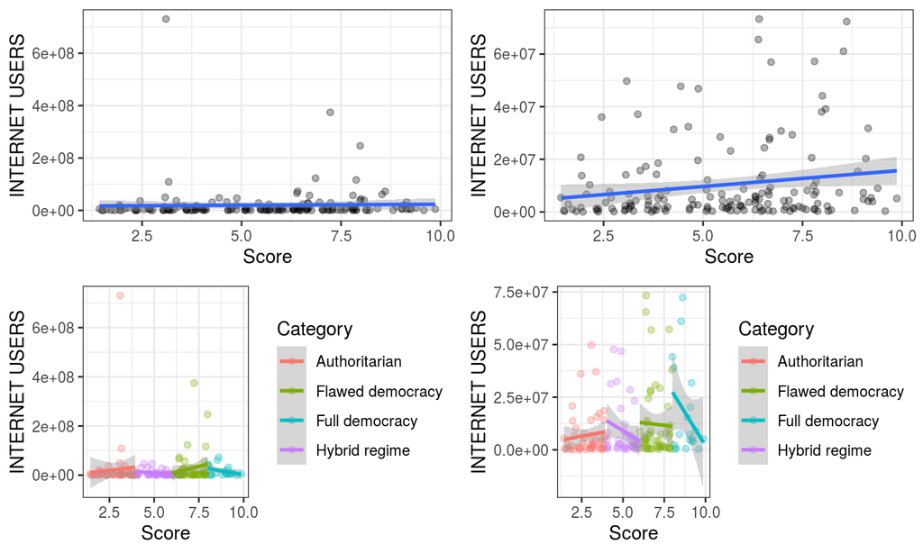

## Internet users and democracy mean table

```
## # A tibble: 4 x 3
##   Category             n  mean
##   <chr>            <int> <dbl>
## 1 Authoritarian       51  2.87
## 2 Flawed democracy    56  7.00
## 3 Full democracy      20  8.83
## 4 Hybrid regime       38  5.11
```

## Internet users and democracy

```
##
## Call:
## lm(formula = `INTERNET USERS` ~ Score, data = iu_dem)
##
## Residuals:
##       Min        1Q    Median        3Q       Max
## -22848878 -18183989 -15874551  -7288638 712287754
##
## Coefficients:
##             Estimate Std. Error t value Pr(>|t|)
## (Intercept) 16167351   14540506   1.112    0.268
## Score         731889    2456561   0.298    0.766
##
## Residual standard error: 68370000 on 163 degrees of freedom
## Multiple R-squared:  0.0005443,  Adjusted R-squared:  -0.005587
## F-statistic: 0.08876 on 1 and 163 DF,  p-value: 0.7661
```

## Internet users and education with with and without outlier

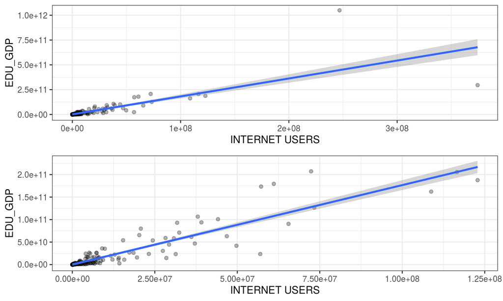

## Internet users and education

```
##
## Call:
## lm(formula = `INTERNET USERS` ~ EDU_GDP, data = INTER_EDU)
##
## Residuals:
##        Min         1Q     Median         3Q        Max
## -108457304   -5403069   -4593277   -1190455  270437578
##
## Coefficients:
##              Estimate Std. Error t value Pr(>|t|)
## (Intercept) 5.433e+06  1.962e+06    2.77  0.00624 **
## EDU_GDP     3.333e-04  2.082e-05   16.01  < 2e-16 ***
## ---
## Signif. codes:  0 '***' 0.001 '**' 0.01 '*' 0.05 '.' 0.1 ' ' 1
##
## Residual standard error: 24560000 on 169 degrees of freedom
## Multiple R-squared:  0.6027, Adjusted R-squared:  0.6003
## F-statistic: 256.4 on 1 and 169 DF,  p-value: < 2.2e-16
```

## Internet users and total GDP with and without outlier

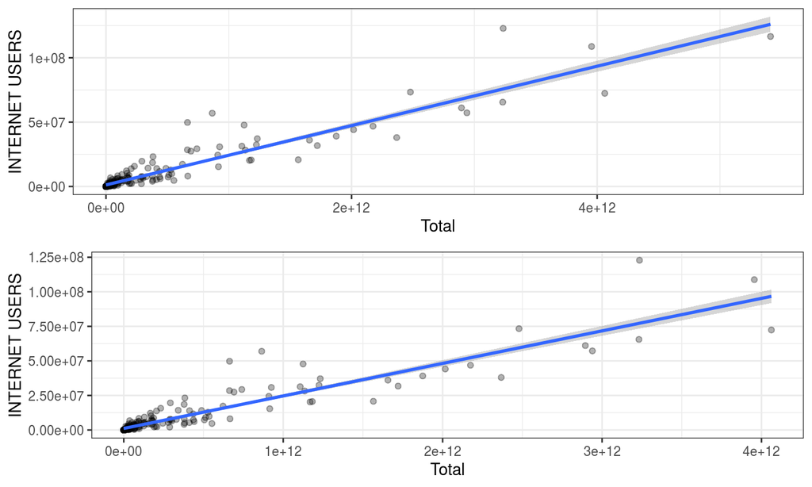

## Internet users and total GDP

```
##
## Call:
## lm(formula = `INTERNET USERS` ~ Total, data = iu_ttgdp)
##
## Residuals:
##       Min        1Q    Median        3Q       Max
## -22510069  -1271185  -1172617    611285  47036339
##
## Coefficients:
##              Estimate Std. Error t value Pr(>|t|)
## (Intercept) 1.232e+06  4.884e+05   2.523   0.0124 *
## Total       2.305e-05  5.833e-07  39.525   <2e-16 ***
## ---
## Signif. codes:  0 '***' 0.001 '**' 0.01 '*' 0.05 '.' 0.1 ' ' 1
##
## Residual standard error: 6558000 on 215 degrees of freedom
## Multiple R-squared:  0.879,  Adjusted R-squared:  0.8785
## F-statistic:  1562 on 1 and 215 DF,  p-value: < 2.2e-16
```

## Internet users and health with and without outlier

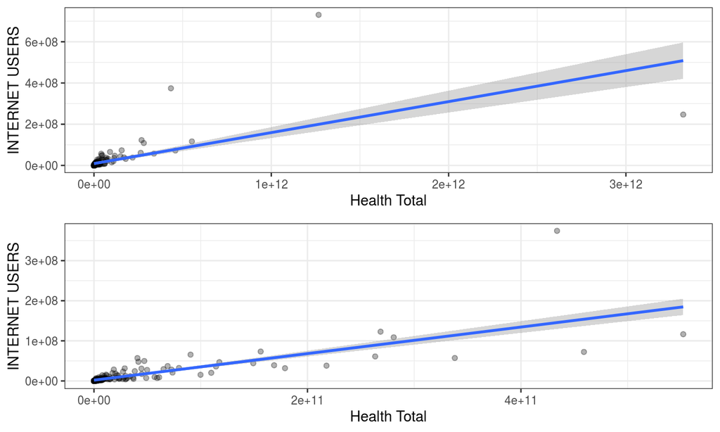

## Internet users and health

```
##
## Call:
## lm(formula = `INTERNET USERS` ~ `Health Total`, data = iu_health)
##
## Residuals:
##        Min         1Q     Median         3Q        Max
## -261710783   -8863437   -7735566   -3758055  531227944
##
## Coefficients:
##                 Estimate Std. Error t value Pr(>|t|)
## (Intercept)    9.112e+06  3.702e+06   2.461   0.0147 *
## `Health Total` 1.503e-04  1.365e-05  11.008   <2e-16 ***
## ---
## Signif. codes:  0 '***' 0.001 '**' 0.01 '*' 0.05 '.' 0.1 ' ' 1
##
## Residual standard error: 49960000 on 188 degrees of freedom
## Multiple R-squared:  0.3919, Adjusted R-squared:  0.3887
## F-statistic: 121.2 on 1 and 188 DF,  p-value: < 2.2e-16
```

## Conclusion

- Summary
  - Region does not affect internet use
  - Education, Economy(GDP) and Health affect internet usage
- Limitation and Challenge
  - Region name not match
  - Data cannot be use directly(GDP,Education percentage)
  - Extra rows (NAs)
  - Data missing